# ttt_p2_lifepak_cleaning

Yama Chang

2024-07-29

```r
# Read TTT Phase 1 data for reference
all_ttt1_data <- read_csv("./data/ttt1_data/cleaned_lifepak_ttt_phase_1.csv")
```

# Initial Cleaning

General plan here:

LifePak data

1. Get a sense of the original data format
2. Do initial cleaning (ordering notifications within participant, creating time of response, combining two csv)
3. Do data cleaning (EMA data, combining day/night data, cleaning other columns, checking/removing duplicated rows)
4. Export a cleaned df with a similar order/columns as TTT Phase 1 df

## Read all lifepak files

```r
# Creating a file list of all csvs in working directory

lifepak_files <- list.files(path = "./data/", pattern = "*.csv", full.names = TRUE) # ensure to use `full.names = TRUE` in the list.files() function to get the full path of the files

# Importing in data without variable names (Have to skip the first few rows because of Qualtrics' format)

all_likepak <- lifepak_files %>%
  map(~read_csv(.x, skip = 1, col_names = FALSE))

# Creating variable names from those same files

all_lifepak_names <- lifepak_files %>%
  map(read_csv) %>%
  map(~slice_head(.x)) %>%
  map(~names(.x)) %>%
  map(~make_clean_names(.x))

# Adding the names to the imported data

named_lifepak <- map2(all_likepak, all_lifepak_names, ~{

  names(.x) <- .y
  .x

})
```

```r
map(1:2, ~{
  enframe(named_lifepak[.x]) %>%
  dplyr::select(value) %>%
  unnest(value) %>%
  skim()
})
```

```
## [[1]]
## ── Data Summary ────────────────────────
##                            Values
## Name                       Piped data
## Number of rows             19903
## Number of columns          58
## _______________________
## Column type frequency:
##   character                27
##   difftime                 2
##   numeric                  28
##   POSIXct                  1
## ________________________
## Group variables            None
##
```

[output cut: 278 more lines]

```r
# Processing the data frames with descending order of column "n"
result <- map(1:2, ~(
  enframe(named_lifepak[.x]) %>%
  dplyr::select(value) %>%
  unnest(value) %>%
  group_by(participant_id) %>%
  tally() %>%
  arrange(desc(n))
)) %>%
  bind_rows()

# Display the result
print(result)
```

```
## # A tibble: 265 × 2
##    participant_id     n
##    <chr>          <int>
##  1 22495-144083     111
##  2 22495-063040     110
##  3 22495-324562     109
##  4 22495-095387     108
##  5 22495-379350     108
##  6 22495-764447     108
##  7 22495-923381     108
##  8 22495-000219     107
##  9 22495-006351     107
## 10 22495-007405     107
## # ℹ 255 more rows
```

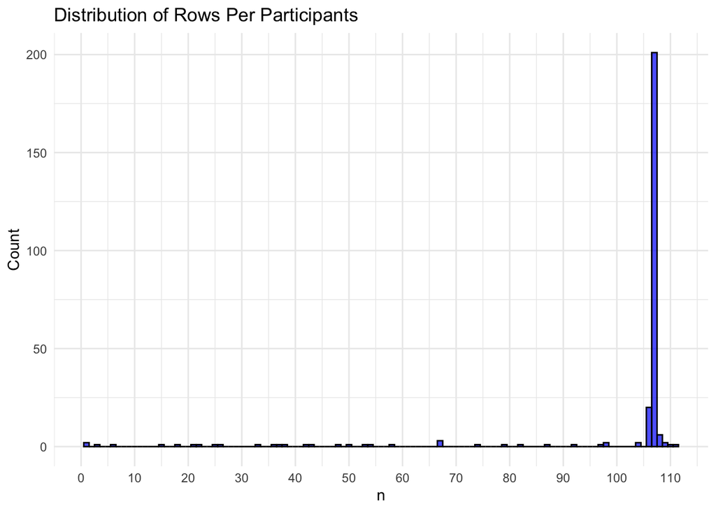

```r
# Plot the distribution of "n": The highest count for pts is 107

ggplot(result, aes(x = n)) +
  geom_histogram(binwidth = 1, fill = "blue", color = "black", alpha = 0.7) +
  labs(title = "Distribution of Rows Per Participants", x = "n", y = "Count") +
  scale_x_continuous(breaks = seq(0, max(result$n), by = 10)) +
  theme_minimal()
```

```r
# Create a simple count table of the distribution of "n"
result %>%
  count(n)
```

```
## # A tibble: 35 × 2
##        n    nn
##    <int> <int>
##  1     1     2
##  2     3     1
##  3     6     1
##  4    15     1
##  5    18     1
##  6    21     1
##  7    22     1
##  8    25     1
##  9    26     1
## 10    33     1
## # ℹ 25 more rows
```

## Create Dataframe

```r
all_df <- map(c(1:2), ~(
  enframe(named_lifepak[.x]) %>%
  dplyr::select(value) %>%
  unnest(value) %>%
  select(-contains("gps")) %>%
  mutate(across(contains("responded"), as.character)
         # across(ends_with("day"), as.numeric),
         # across(ends_with("night"), as.numeric))
  )
)
) %>%
  bind_rows() %>%
  print()
```

```
## # A tibble: 26,460 × 54
##    participant_id notification_time   session_name notification_no responded
##    <chr>          <dttm>              <chr>                  <dbl> <chr>
##  1 22495-786805   2021-02-01 07:43:01 3T Project                 1 1
##  2 22495-786805   2021-02-01 12:09:42 3T Project                 2 User didn't …
##  3 22495-786805   2021-02-01 16:28:05 3T Project                 3 1
##  4 22495-786805   2021-02-01 18:44:11 3T Project                 4 1
##  5 22495-786805   2021-02-02 08:16:33 3T Project                 5 1
##  6 22495-786805   2021-02-02 12:04:08 3T Project                 6 User didn't …
##  7 22495-786805   2021-02-02 15:50:30 3T Project                 7 1
##  8 22495-786805   2021-02-02 18:26:04 3T Project                 8 1
##  9 22495-786805   2021-02-03 08:17:31 3T Project                 9 1
## 10 22495-786805   2021-02-03 11:03:45 3T Project                10 User didn't …
## # ℹ 26,450 more rows
## # ℹ 49 more variables: completed_session <dbl>, session_instance <dbl>,
## #   session_instance_response_lapse <time>, session_length <time>,
## #   reminders_delivered <dbl>, reminder_1_11 <chr>, reminder_2_12 <chr>,
## #   reminder_3_13 <chr>, reminder_4_14 <chr>, reminder_5_15 <chr>,
## #   ema_sad_16 <dbl>, ema_bad_17 <dbl>, ema_interest_18 <dbl>,
## #   ema_energy_19 <dbl>, ema_focus_20 <dbl>, ema_movement_21 <dbl>, …
```

```r
# Print the number of rows and columns

cat("Number of rows:", nrow(all_df), "\n")
```

```
## Number of rows: 26460
```

```r
cat("Number of columns:", ncol(all_df), "\n")
```

```
## Number of columns: 54
```

## Other Initial Cleaning

```r
## This is going through this for one test data frame, we'll want a function that will let us map through all the data frames in our list

temp <- all_df %>%
  group_by(participant_id) %>%
  mutate(response_time = case_when(
    responded != "User didn't respond to this notification" ~ notification_time + session_instance_response_lapse + session_length,
    TRUE ~ NA_POSIXct_
      )
    ) %>%
  arrange(notification_time, .by_group = TRUE) %>%
  mutate(response_no = row_number(),
         time_diff = as.numeric(response_time - lag(notification_time)), # This is in hours but I just need to make sure there aren't any negatives
         ) %>%
  ungroup() %>%
  relocate(participant_id, response_no, notification_no, notification_time, response_time, time_diff) %>%
  print()
```

```
## # A tibble: 26,460 × 57
##    participant_id response_no notification_no notification_time
##    <chr>                <int>           <dbl> <dttm>
##  1 22495-000219             1               1 2021-11-22 08:41:00
##  2 22495-000219             2               2 2021-11-22 11:20:37
##  3 22495-000219             3               3 2021-11-22 14:03:59
##  4 22495-000219             4               4 2021-11-22 16:17:10
##  5 22495-000219             5               1 2021-11-22 22:23:08
##  6 22495-000219             6               5 2021-11-23 08:35:08
##  7 22495-000219             7               6 2021-11-23 11:19:15
##  8 22495-000219             8               7 2021-11-23 14:46:46
##  9 22495-000219             9               8 2021-11-23 17:06:35
## 10 22495-000219            10               2 2021-11-23 21:41:08
## # ℹ 26,450 more rows
## # ℹ 53 more variables: response_time <dttm>, time_diff <dbl>,
## #   session_name <chr>, responded <chr>, completed_session <dbl>,
## #   session_instance <dbl>, session_instance_response_lapse <time>,
## #   session_length <time>, reminders_delivered <dbl>, reminder_1_11 <chr>,
## #   reminder_2_12 <chr>, reminder_3_13 <chr>, reminder_4_14 <chr>,
## #   reminder_5_15 <chr>, ema_sad_16 <dbl>, ema_bad_17 <dbl>, …
```

```r
## Want to check that response time for first notification isn't later than the next notification (This is hack-y right now, but a positive number indicates no out of order responses)

temp %>%
  filter(!is.na(time_diff)) %>%
  count(time_diff) %>%
  arrange(time_diff) %>%
  slice_head()
```

```
## # A tibble: 1 × 2
##   time_diff     n
##       <dbl> <int>
## 1      1.06     1
```

```r
skim(temp)
```

Data summary

| Name | temp |
| --- | --- |
| Number of rows | 26460 |
| Number of columns | 57 |
| _______________________ |  |
| Column type frequency: |  |
| character | 23 |
| difftime | 2 |
| numeric | 30 |
| POSIXct | 2 |
| ________________________ |  |
| Group variables | None |

**Variable type: character**

| skim_variable | n_missing | complete_rate | min | max | empty | n_unique | whitespace |
| --- | --- | --- | --- | --- | --- | --- | --- |
| participant_id | 0 | 1.00 | 12 | 12 | 0 | 264 | 0 |
| session_name | 0 | 1.00 | 10 | 19 | 0 | 2 | 0 |
| responded | 0 | 1.00 | 1 | 40 | 0 | 2 | 0 |
| reminder_1_11 | 12666 | 0.52 | 6 | 6 | 0 | 1 | 0 |
| reminder_2_12 | 12682 | 0.52 | 6 | 6 | 0 | 1 | 0 |
| reminder_3_13 | 12695 | 0.52 | 6 | 6 | 0 | 1 | 0 |
| reminder_4_14 | 12706 | 0.52 | 6 | 6 | 0 | 1 | 0 |
| reminder_5_15 | 12715 | 0.52 | 6 | 6 | 0 | 1 | 0 |
| thankyou_24 | 12802 | 0.52 | 6 | 6 | 0 | 1 | 0 |
| reminder_1_25 | 23201 | 0.12 | 6 | 6 | 0 | 1 | 0 |
| reminder_2_26 | 23202 | 0.12 | 6 | 6 | 0 | 1 | 0 |
| reminder_3_27 | 23202 | 0.12 | 6 | 6 | 0 | 1 | 0 |
| reminder_4_28 | 23206 | 0.12 | 6 | 6 | 0 | 1 | 0 |
| reminder_5_29 | 23207 | 0.12 | 6 | 6 | 0 | 1 | 0 |
| best | 23246 | 0.12 | 1 | 360 | 0 | 1975 | 0 |
| worst | 23241 | 0.12 | 1 | 563 | 0 | 1756 | 0 |
| other | 23242 | 0.12 | 1 | 314 | 0 | 985 | 0 |
| thankyou_41 | 23251 | 0.12 | 6 | 6 | 0 | 1 | 0 |
| intro_feedback_1 | 26094 | 0.01 | 6 | 6 | 0 | 1 | 0 |
| intro_feedback_2 | 26094 | 0.01 | 6 | 6 | 0 | 1 | 0 |
| experience_other | 26110 | 0.01 | 2 | 198 | 0 | 127 | 0 |
| thankyou_feedback | 26109 | 0.01 | 6 | 6 | 0 | 1 | 0 |
| device_id | 0 | 1.00 | 63 | 83 | 0 | 257 | 0 |

**Variable type: difftime**

| skim_variable | n_missing | complete_rate | min | max | median | n_unique |
| --- | --- | --- | --- | --- | --- | --- |
| session_instance_response_lapse | 8817 | 0.67 | 1 secs | 86334 secs | 00:08:20 | 4474 |
| session_length | 9258 | 0.65 | 5 secs | 148777 secs | 00:00:32 | 653 |

**Variable type: numeric**

| skim_variable | n_missing | complete_rate | mean | sd | p0 | p25 | p50 | p75 | p100 | hist |
| --- | --- | --- | --- | --- | --- | --- | --- | --- | --- | --- |
| response_no | 0 | 1.00 | 52.88 | 30.89 | 1.00 | 26.00 | 52.0 | 80.00 | 111.00 | ▇▇▇▇▆ |
| notification_no | 0 | 1.00 | 34.93 | 25.27 | 1.00 | 12.00 | 30.0 | 57.00 | 84.00 | ▇▅▃▃▃ |
| time_diff | 9409 | 0.64 | 10.12 | 46.52 | 1.06 | 2.98 | 3.8 | 5.22 | 1518.77 | ▇▁▁▁▁ |
| completed_session | 0 | 1.00 | 0.65 | 0.48 | 0.00 | 0.00 | 1.0 | 1.00 | 1.00 | ▅▁▁▁▇ |
| session_instance | 8817 | 0.67 | 27.20 | 21.31 | 1.00 | 9.00 | 21.0 | 42.50 | 85.00 | ▇▅▃▂▁ |
| reminders_delivered | 0 | 1.00 | 0.88 | 0.93 | 0.00 | 0.00 | 1.0 | 2.00 | 10.00 | ▇▁▁▁▁ |
| ema_sad_16 | 12778 | 0.52 | 32.68 | 32.69 | 0.00 | 0.00 | 23.0 | 61.00 | 100.00 | ▇▃▂▂▂ |
| ema_bad_17 | 12770 | 0.52 | 30.69 | 32.35 | 0.00 | 0.00 | 20.0 | 58.00 | 100.00 | ▇▂▂▂▂ |
| ema_interest_18 | 12770 | 0.52 | 37.52 | 33.29 | 0.00 | 4.00 | 30.0 | 67.00 | 100.00 | ▇▃▂▃▃ |
| ema_energy_19 | 12769 | 0.52 | 50.05 | 36.61 | 0.00 | 12.00 | 57.0 | 83.00 | 100.00 | ▇▃▂▅▇ |
| ema_focus_20 | 12774 | 0.52 | 42.79 | 35.80 | 0.00 | 5.00 | 37.0 | 75.00 | 100.00 | ▇▃▂▃▅ |
| ema_movement_21 | 12767 | 0.52 | 37.64 | 34.19 | 0.00 | 3.00 | 29.0 | 69.00 | 100.00 | ▇▃▂▃▃ |
| ema_control_22 | 12774 | 0.52 | 37.38 | 34.65 | 0.00 | 1.00 | 28.0 | 69.00 | 100.00 | ▇▃▂▃▃ |
| ema_fun_23 | 12770 | 0.52 | 55.79 | 32.97 | 0.00 | 27.00 | 61.0 | 84.00 | 100.00 | ▆▅▃▇▇ |
| ema_sad_30 | 23219 | 0.12 | 34.87 | 34.28 | 0.00 | 0.00 | 25.0 | 66.00 | 100.00 | ▇▃▂▂▂ |
| ema_bad_31 | 23222 | 0.12 | 32.16 | 33.74 | 0.00 | 0.00 | 21.0 | 61.00 | 100.00 | ▇▂▂▂▂ |
| ema_interest_32 | 23220 | 0.12 | 36.12 | 33.69 | 0.00 | 2.00 | 27.0 | 65.00 | 100.00 | ▇▃▂▃▂ |
| ema_energy_33 | 23220 | 0.12 | 49.12 | 37.11 | 0.00 | 11.00 | 53.5 | 83.00 | 100.00 | ▇▃▂▅▆ |
| ema_focus_34 | 23220 | 0.12 | 42.05 | 35.91 | 0.00 | 5.00 | 34.0 | 75.00 | 100.00 | ▇▃▂▃▅ |
| ema_movement_35 | 23219 | 0.12 | 36.15 | 34.43 | 0.00 | 1.00 | 26.0 | 67.00 | 100.00 | ▇▃▂▃▃ |
| ema_control_36 | 23221 | 0.12 | 37.56 | 35.25 | 0.00 | 0.00 | 28.0 | 69.00 | 100.00 | ▇▃▂▃▃ |
| ema_fun_37 | 23220 | 0.12 | 62.23 | 32.12 | 0.00 | 37.00 | 69.0 | 91.00 | 100.00 | ▃▂▃▆▇ |
| five_times_a_day | 26100 | 0.01 | 45.40 | 32.60 | 0.00 | 15.00 | 45.5 | 72.25 | 100.00 | ▇▅▃▆▅ |
| notice_change | 26103 | 0.01 | 55.88 | 30.01 | 0.00 | 33.00 | 61.0 | 78.00 | 100.00 | ▅▅▅▇▆ |
| aware_mood | 26105 | 0.01 | 66.80 | 28.69 | 0.00 | 55.50 | 71.0 | 88.00 | 100.00 | ▂▂▃▇▇ |
| aware_felt_worse | 26106 | 0.01 | 34.16 | 28.15 | 0.00 | 10.00 | 30.5 | 53.00 | 100.00 | ▇▆▃▂▂ |
| aware_felt_better | 26107 | 0.01 | 51.53 | 29.21 | 0.00 | 29.00 | 53.0 | 72.00 | 100.00 | ▅▅▆▇▅ |
| instruct_helpful | 26108 | 0.01 | 77.53 | 23.59 | 0.00 | 67.00 | 81.0 | 99.00 | 100.00 | ▁▁▂▅▇ |
| easy_use | 26108 | 0.01 | 84.26 | 22.53 | 0.00 | 77.00 | 95.0 | 100.00 | 100.00 | ▁▁▁▂▇ |
| time_complete | 26113 | 0.01 | 6.31 | 10.99 | 0.00 | 2.00 | 4.0 | 6.00 | 124.00 | ▇▁▁▁▁ |

**Variable type: POSIXct**

| skim_variable | n_missing | complete_rate | min | max | median | n_unique |
| --- | --- | --- | --- | --- | --- | --- |
| notification_time | 0 | 1.00 | 2021-02-01 07:43:01 | 2023-08-14 08:00:00 | 2022-04-11 14:21:26 | 26330 |
| response_time | 9258 | 0.65 | 2021-02-01 08:38:48 | 2023-08-14 08:00:47 | 2022-03-03 13:33:27 | 17198 |

# Data Cleaning

## Clean EMA items

```r
# Start cleaning EMA data

df_ema <- temp

# Convert notification_time to a POSIXct datetime object
df_ema <- df_ema %>%
  mutate(notification_time = ymd_hms(notification_time))

# Create a new column based on the time of day
df_ema_1 <- df_ema %>%
  mutate(time_of_day = if_else(hour(notification_time) > 19 | (hour(notification_time) == 19 & minute(notification_time) > 0), "night", "day")) %>%
  select(c(1:6), time_of_day, everything())

# Pivot the data to long format

df_ema_long <- df_ema_1 %>%
  pivot_longer(cols = starts_with("ema_"),
               names_to = c("ema", "type_num"),
               names_pattern = "ema_(.*)_(.*)") %>%
  mutate(type = ifelse(as.numeric(type_num) >= 16 & as.numeric(type_num) <= 23, "day", "night")) %>%
  select(-type_num)

# Create the check_time column
df_ema_long_1 <- df_ema_long %>%
  mutate(check_time = if_else(time_of_day == type, 1, 0))

# Remove rows where check_time is 0
df_ema_long_2 <- df_ema_long_1 %>%
  filter(check_time == 1) %>%
  select(-check_time, -type)

# Transform to wide format again
df_ema_wide <- df_ema_long_2 %>%
  pivot_wider(names_from = ema, values_from = value)
```

## Clean variables that start with “reminder”

```r
# Since for "reminder" columns, it's recorded either for day or night time.  The goal is to coalesce the values of the pairs of columns (i.e., merge them, keeping the non-NA value).

# Merge / coalesce the specified columns
df_ema_wide_1 <- df_ema_wide %>%
  mutate(
    reminder_1 = coalesce(reminder_1_11, reminder_1_25),
    reminder_2 = coalesce(reminder_2_12, reminder_2_26),
    reminder_3 = coalesce(reminder_3_13, reminder_3_27),
    reminder_4 = coalesce(reminder_4_14, reminder_4_28),
    reminder_5 = coalesce(reminder_5_15, reminder_5_29),
    thankyou = coalesce(thankyou_24, thankyou_41)
  ) %>%
  select(-reminder_1_11, -reminder_2_12, -reminder_3_13, -reminder_4_14, -reminder_5_15,
         -reminder_1_25, -reminder_2_26, -reminder_3_27, -reminder_4_28, -reminder_5_29,
         -thankyou_24, -thankyou_41)
```

## Check `3T Project Feedback` variables

```r
# Grab variables from the `3T Project Feedback` questions
df_ema_wide_other <- df_ema_wide_1 %>% select(1, 2, 4, 8, 18:29)

# Remove all NA rows to check these rows
# It looks like these data were not seperated by day/night so we can keep them
df_ema_wide_other_1 <- df_ema_wide_other %>%
  filter(rowSums(is.na(select(., 5:16))) < 12)

# Are all of the data from `3T Project Feedback`? YES!
table(df_ema_wide_other$session_name)
```

```
##
##          3T Project 3T Project Feedback
##               26016                 444
```

## Other cleaning

We’ve cleaned the majority of the columns. Now, I want to make sure we have a similar order of columns as TTT 1, remove irrelevant columns, and create any necessary new columns.

```r
# Create a new column `lifepak_id` by extracting the numeric value after the hyphen
df_ema_wide_2 <- df_ema_wide_1 %>%
  mutate(lifepak_id = str_extract(participant_id, "(?<=-)[0-9]+"))

# Remove some logical columns and reorder current df
df_ema_wide_3 <- df_ema_wide_2 %>%
  select(1, 45, 2:5, 10, 30, 9, 11:13, 8, 14, 39:44, 31:38, 15:17, 20:28)
```

## Check duplicates

```r
# Assuming named_lifepak is a list of data frames
# Extract the column names of the two data frames
colnames_df1 <- colnames(named_lifepak[[1]])
colnames_df2 <- colnames(named_lifepak[[2]])

# Compare the column names
same_colnames <- identical(colnames_df1, colnames_df2)

# Print the result
if (same_colnames) {
  cat("The column names are exactly the same and in the same order for both data frame.\n")
} else {
  cat("The column names are not the same or not in the same order.\n")
}
```

```
## The column names are exactly the same and in the same order for both data frame.
```

```r
lifepak_df1 <- named_lifepak[[1]]
lifepak_df2 <- named_lifepak[[2]]

IDlist1 <- lifepak_df1$participant_id
IDlist2 <- lifepak_df2$participant_id

# Find duplicates between the two lists
duplicates <- intersect(IDlist1, IDlist2)

# Check if there are any duplicates
if (length(duplicates) > 0) {
  print("Duplicates found:")
  print(duplicates)
} else {
  print("No duplicates found.")
}
```

```
## [1] "Duplicates found:"
## [1] "22495-587713"
```

## Clean individual data: duplicates from two csv df

Participant 587713 has some unusual data. For `notification_no` 102 and 103, they are the same notification, but the data were separated and stored in different data frames. We manually cleaned it here by coalescing it. Then, we adjusted the `notification_no` from 104-106 to 103-105.

```r
df_ema_wide_4 <- df_ema_wide_3

# Since there's only one pt due to some weird error, let's manually fix it
df_ema_wide_4$thankyou[df_ema_wide_4$lifepak_id == 587713 & df_ema_wide_4$response_no == 102] <- "Viewed"

df_ema_wide_4$energy[df_ema_wide_4$lifepak_id == 587713 & df_ema_wide_4$response_no == 102] <- 0

### Remove response no 103
df_ema_wide_5 <- df_ema_wide_4 %>%
  filter(!(df_ema_wide_4$lifepak_id == 587713 & df_ema_wide_4$response_no == 103))

### We will adjust response_no later in the next step!
```

## Clean individual data: duplicated notifications

For duplicated `notification_time` of each participant, we removed rows without data. If both rows are all NA, we kept the first row.

```r
# Are there any duplicated notifications across the whole df? YESSSS
any(duplicated(df_ema_wide_5$lifepak_id, df_ema_wide_5$notification_time))
```

```
## [1] TRUE
```

```r
# Check these visually first!
duplicates <- df_ema_wide_5 %>%
  group_by(lifepak_id, notification_time) %>%
  filter(n() > 1) %>%
  ungroup()

# SO there're 34 rows that contains duplicates (aka we need to remove row without data)
# WE can remove the rows based on lifepak_id AND response_no
# N - 18 = 26441
df_ema_wide_6 <- df_ema_wide_5

df_ema_wide_7 <- df_ema_wide_6 %>%
  filter(
    !(lifepak_id == "056379" & response_no == 57) &
      !(lifepak_id == "056379" & response_no == 90) &
      !(lifepak_id == "063040" & response_no == 28) &
      !(lifepak_id == "063040" & response_no == 29) &
      !(lifepak_id == "063040" & response_no == 62) &
      !(lifepak_id == "095387" & response_no == 108) &
      !(lifepak_id == "144083" & response_no == 55) &
      !(lifepak_id == "144083" & response_no == 69) &
      !(lifepak_id == "144083" & response_no == 85) &
      !(lifepak_id == "144083" & response_no == 86) &
      !(lifepak_id == "324562" & response_no == 41) &
      !(lifepak_id == "324562" & response_no == 83) &
      !(lifepak_id == "324562" & response_no == 84) &
      !(lifepak_id == "379350" & response_no == 54) &
      !(lifepak_id == "764447" & response_no == 36) &
      !(lifepak_id == "849302" & response_no == 47) &
      !(lifepak_id == "923381" & response_no == 40) &
      !(lifepak_id == "987930" & response_no == 61)
    )

# Create the new column response_no based on row numbers
df_ema_wide_8 <- df_ema_wide_7 %>%
  arrange(lifepak_id, notification_time) %>%
  group_by(lifepak_id) %>%
  mutate(response_no = row_number()) %>%
  ungroup()

# Print the number of rows and columns

cat("Number of rows:", nrow(df_ema_wide_8), "\n")
```

```
## Number of rows: 26441
```

```r
cat("Number of columns:", ncol(df_ema_wide_8), "\n")
```

```
## Number of columns: 40
```

## Export the data frame

```r
### Export to csv
write_csv(df_ema_wide_8, paste0("./cleaned_data/cleaned_lifepak_ttt_phase_2_", Sys.Date(),".csv"))
```

## Next steps:

- Join all the EMA columns to Qualdrics dataframe (Jeremy’s working on it so not yet)
- Be done!